# Prediction Assignment Writeup

Audrei Marcelo

21 de março de 2018

## Background

Using devices such as Jawbone Up, Nike FuelBand, and Fitbit it is now possible to collect a large amount of data about personal activity relatively inexpensively. These type of devices are part of the quantified self movement – a group of enthusiasts who take measurements about themselves regularly to improve their health, to find patterns in their behavior, or because they are tech geeks. One thing that people regularly do is quantify how much of a particular activity they do, but they rarely quantify how well they do it. In this project, your goal will be to use data from accelerometers on the belt, forearm, arm, and dumbell of 6 participants. They were asked to perform barbell lifts correctly and incorrectly in 5 different ways. More information is available from the website here: http://web.archive.org/web/20161224072740/http:/groupware.les.inf.puc-rio.br/har (see the section on the Weight Lifting Exercise Dataset).

## Data

The data for this project come from this source:

http://web.archive.org/web/20161224072740/http:/groupware.les.inf.puc-rio.br/har

The training data for this project are available here:

https://d396qusza40orc.cloudfront.net/predmachlearn/pml-training.csv

The test data are available here:

https://d396qusza40orc.cloudfront.net/predmachlearn/pml-testing.csv

## Environment Setup

```r
library(knitr)
library(caret)
```

```r
library(rpart)
library(rpart.plot)
library(rattle)
library(randomForest)
library(corrplot)
library(backports)
set.seed(234)
```

## Downloading and Loading Data

```r
TrainUrl <- "https://d396qusza40orc.cloudfront.net/predmachlearn/pml-training.csv"
TrainFile<-"pml-traininig.csv"
download.file(TrainUrl, destfile = TrainFile)
training <- read.csv(TrainFile)
dim(training)
```

```
## [1] 19622   160
```

```r
TestUrl  <- "https://d396qusza40orc.cloudfront.net/predmachlearn/pml-testing.csv"
TestFile<-"pml-testing.csv"
download.file(TestUrl, destfile = TestFile)
testing  <- read.csv(TestFile)
dim(testing)
```

```
## [1]  20 160
```

## Create Partition

```r
inTrain  <- createDataPartition(training$classe, p=0.7, list=FALSE)
Train <- training[inTrain, ]
Test  <- training[-inTrain, ]
dim(Train)
```

```
## [1] 13737   160
```

```r
dim(Test)
```

```
## [1] 5885  160
```

## Cleaning Data

Cleaning the data to use the dataset in model generation.

```r
Near0 <- nearZeroVar(Train)
Train <- Train[, -Near0]
Test  <- Test[, -Near0]
dim(Train)
```

```
## [1] 13737   105
```

```r
dim(Test)
```

```
## [1] 5885  105
```

```r
All_NA    <- sapply(Train, function(x) mean(is.na(x))) > 0.95
Train <- Train[, All_NA==FALSE]
Test  <- Test[, All_NA==FALSE]
dim(Train)
```

```
## [1] 13737    59
```

```r
dim(Test)
```

```
## [1] 5885   59
```

```r
Train <- Train[, -(1:5)]
Test  <- Test[, -(1:5)]
dim(Train)
```

```
## [1] 13737    54
```

## Predition Models

Generating and evaluating the results of two models.

```r
##a. Random Forests
# model fit
set.seed(234)
controlRF <- trainControl(method="cv", number=3, verboseIter=FALSE)
modelFitRF <- train(classe ~ ., data=Train, method="rf",
                          trControl=controlRF)
modelFitRF$finalModel
```

```
##
## Call:
##  randomForest(x = x, y = y, mtry = param$mtry)
##                Type of random forest: classification
##                      Number of trees: 500
## No. of variables tried at each split: 27
##
##         OOB estimate of  error rate: 0.2%
## Confusion matrix:
##      A    B    C    D    E class.error
## A 3906    0    0    0    0 0.000000000
## B    7 2646    4    1    0 0.004514673
## C    0    5 2391    0    0 0.002086811
## D    0    0    7 2245    0 0.003108348
## E    0    0    0    4 2521 0.001584158
```

```r
predictRF <- predict(modelFitRF, newdata=Test)
confusionMatRF <- confusionMatrix(predictRF, Test$classe)
confusionMatRF
```

```
## Confusion Matrix and Statistics
##
##           Reference
## Prediction    A    B    C    D    E
##          A 1673    2    0    0    0
##          B    1 1134    1    0    0
##          C    0    3 1025    2    0
##          D    0    0    0  960    3
##          E    0    0    0    2 1079
##
## Overall Statistics
##
##                Accuracy : 0.9976
##                  95% CI : (0.996, 0.9987)
##     No Information Rate : 0.2845
##     P-Value [Acc > NIR] : < 2.2e-16
##
##                   Kappa : 0.997
##  Mcnemar's Test P-Value : NA
##
## Statistics by Class:
##
##                      Class: A Class: B Class: C Class: D Class: E
## Sensitivity            0.9994   0.9956   0.9990   0.9959   0.9972
## Specificity            0.9995   0.9996   0.9990   0.9994   0.9996
## Pos Pred Value         0.9988   0.9982   0.9951   0.9969   0.9981
## Neg Pred Value         0.9998   0.9989   0.9998   0.9992   0.9994
## Prevalence             0.2845   0.1935   0.1743   0.1638   0.1839
## Detection Rate         0.2843   0.1927   0.1742   0.1631   0.1833
## Detection Prevalence   0.2846   0.1930   0.1750   0.1636   0.1837
## Balanced Accuracy      0.9995   0.9976   0.9990   0.9976   0.9984
```

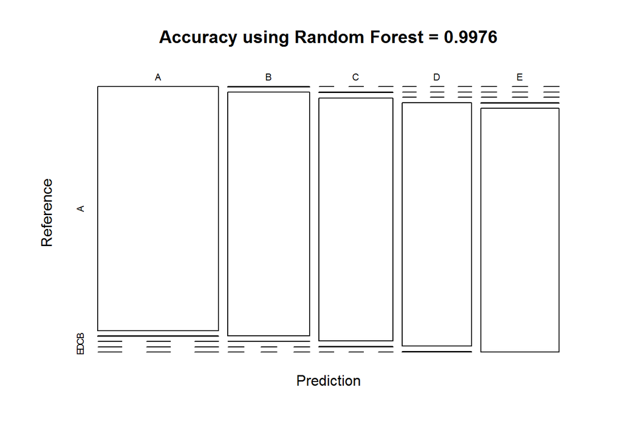

```r
plot(confusionMatRF$table, col = confusionMatRF$byClass,
     main = paste("Accuracy using Random Forest =",
                  round(confusionMatRF$overall['Accuracy'], 4)))
```

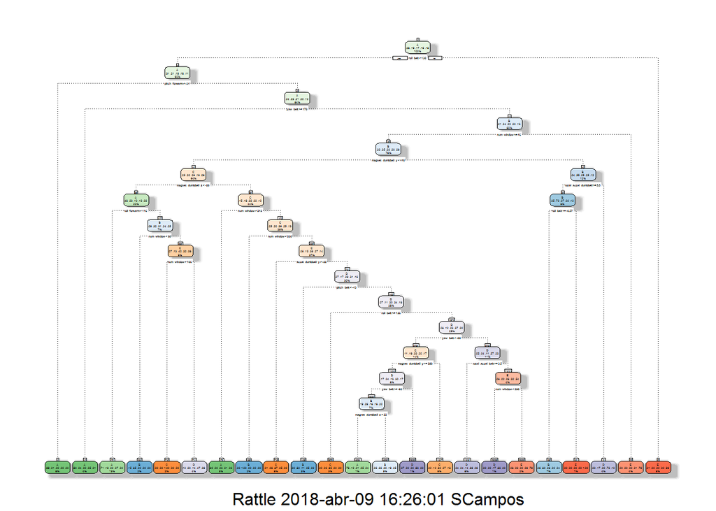

```r
##b. Decision Tree
# model fit
set.seed(234)
modelFitTree <- rpart(classe ~ ., data=Train, method="class")
fancyRpartPlot(modelFitTree)
```

```r
predictTree <- predict(modelFitTree, newdata=Test, type="class")
confusionMatTree <- confusionMatrix(predictTree, Test$classe)
confusionMatTree
```

```
## Confusion Matrix and Statistics
##
##           Reference
## Prediction    A    B    C    D    E
##          A 1561  175   29   66   30
##          B   43  776   97   87   92
##          C    9   74  778   42   68
##          D   41  112  122  720   81
##          E   20    2    0   49  811
##
## Overall Statistics
##
##                Accuracy : 0.7895
##                  95% CI : (0.7788, 0.7998)
##     No Information Rate : 0.2845
##     P-Value [Acc > NIR] : < 2.2e-16
##
##                   Kappa : 0.7327
##  Mcnemar's Test P-Value : < 2.2e-16
##
## Statistics by Class:
##
##                      Class: A Class: B Class: C Class: D Class: E
## Sensitivity            0.9325   0.6813   0.7583   0.7469   0.7495
## Specificity            0.9288   0.9328   0.9603   0.9277   0.9852
## Pos Pred Value         0.8388   0.7087   0.8012   0.6691   0.9195
## Neg Pred Value         0.9719   0.9242   0.9495   0.9493   0.9458
## Prevalence             0.2845   0.1935   0.1743   0.1638   0.1839
## Detection Rate         0.2653   0.1319   0.1322   0.1223   0.1378
## Detection Prevalence   0.3162   0.1861   0.1650   0.1828   0.1499
## Balanced Accuracy      0.9306   0.8070   0.8593   0.8373   0.8674
```

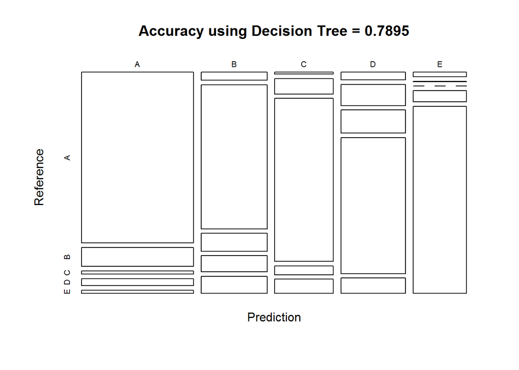

```r
plot(confusionMatTree$table, col = confusionMatTree$byClass,
     main = paste("Accuracy using Decision Tree =",
                  round(confusionMatTree$overall['Accuracy'], 4)))
```

## Model Selection

To choose the model was calculated the accuracy. The most accurate model was random forest and will be used to predict 20 different test cases.

## Test

```r
# Applying the select model in test dataset
predict <- predict(modelFitRF, newdata=testing)
predict
```

```
##  [1] B A B A A E D B A A B C B A E E A B B B
## Levels: A B C D E
```